# Assignment2-彭礼敏18333145

彭礼敏 18333145

2020/20/19

设置工作路径并读入数据，并且查看数据的基本特征：

```r
setwd("D:/PLM/2020Autumn/ML&DM/Assignment 2")
df <- read.csv("train.csv")
str(df)
```

```
## 'data.frame':    58919 obs. of  23 variables:
##  $ sku              : int  2 5 7 9 10 11 16 19 20 22 ...
##  $ national_inv     : int  4 2 4 0 300 1 9635 4 22 218 ...
##  $ lead_time        : int  2 16 4 9 8 12 8 8 4 9 ...
##  $ in_transit_qty   : int  0 0 0 0 0 0 26 0 16 113 ...
##  $ forecast_3_month : int  0 0 0 1 0 0 0 0 18 218 ...
##  $ forecast_6_month : int  0 0 0 1 0 0 0 0 36 323 ...
##  $ forecast_9_month : int  0 0 0 1 0 0 0 0 54 353 ...
##  $ sales_1_month    : int  0 0 0 0 0 0 88 1 1 61 ...
##  $ sales_3_month    : int  0 0 0 0 40 1 267 7 20 147 ...
##  $ sales_6_month    : int  0 0 0 0 100 2 538 7 36 377 ...
##  $ sales_9_month    : int  0 0 0 0 122 2 875 9 51 558 ...
##  $ min_bank         : int  0 1 0 0 7 2 97 2 0 62 ...
##  $ potential_issue  : int  0 0 0 0 0 0 0 0 0 0 ...
##  $ pieces_past_due  : int  0 0 0 0 0 0 0 0 0 0 ...
##  $ perf_6_month_avg : num  0.18 0.31 0.73 0.86 0 0.77 0.12 0.62 0.73 0.85 ...
##  $ perf_12_month_avg: num  0.31 0.4 0.78 0.69 0 0.73 0.12 0.62 0.78 0.82 ...
##  $ local_bo_qty     : int  0 0 0 0 0 0 0 0 0 0 ...
##  $ deck_risk        : int  1 0 0 0 0 1 0 1 0 0 ...
##  $ oe_constraint    : int  0 0 0 0 0 0 0 0 0 0 ...
##  $ ppap_risk        : int  0 0 0 0 0 0 0 1 0 0 ...
##  $ stop_auto_buy    : int  1 1 1 1 1 1 1 1 1 1 ...
##  $ rev_stop         : int  0 0 0 0 0 0 0 0 0 0 ...
##  $ went_on_backorder: int  0 0 0 0 0 0 0 0 0 0 ...
```

```r
#install.packages("Hmisc")
library(Hmisc)
describe(df)
```

```
## df
##
##  23  Variables      58919  Observations
## --------------------------------------------------------------------------------
## sku
##        n  missing distinct     Info     Mean      Gmd      .05      .10
##    58919        0    58919        1    42054    28061     4187     8376
##      .25      .50      .75      .90      .95
##    21069    41948    63047    75816    80009
##
## lowest :     2     5     7     9    10, highest: 84165 84166 84167 84169 84171
## --------------------------------------------------------------------------------
## national_inv
##        n  missing distinct     Info     Mean      Gmd      .05      .10
##    58919        0     2492    0.998    199.4    363.8        0        0
##      .25      .50      .75      .90      .95
##        3       11       54      243      586
##
## lowest :  -401  -213  -152  -126  -120, highest: 73066 73128 73148 75254 75813
## --------------------------------------------------------------------------------
## lead_time
##        n  missing distinct     Info     Mean      Gmd      .05      .10
##    58919        0       27    0.903    6.916    3.781        2        2
##      .25      .50      .75      .90      .95
##        4        8        8       12       12
##
## lowest :  0  1  2  3  4, highest: 22 24 25 26 28
## --------------------------------------------------------------------------------
## in_transit_qty
##        n  missing distinct     Info     Mean      Gmd      .05      .10
##    58919        0      798    0.482    17.14    32.97        0        0
##      .25      .50      .75      .90      .95
##        0        0        0       13       55
##
## lowest :    0    1    2    3    4, highest: 3706 3715 3728 3732 3872
## --------------------------------------------------------------------------------
## forecast_3_month
##        n  missing distinct     Info     Mean      Gmd      .05      .10
##    58919        0     1536    0.793    87.25    163.6        0        0
##      .25      .50      .75      .90      .95
```

[output cut: 112 more lines]

```
## stop_auto_buy
##        n  missing distinct     Info      Sum     Mean      Gmd
##    58919        0        2    0.052    57870   0.9822  0.03497
##
## --------------------------------------------------------------------------------
## rev_stop
##         n   missing  distinct      Info       Sum      Mean       Gmd
##     58919         0         2     0.001        15 0.0002546 0.0005091
##
## --------------------------------------------------------------------------------
## went_on_backorder
##        n  missing distinct     Info      Sum     Mean      Gmd
##    58919        0        2    0.399     9295   0.1578   0.2657
##
## --------------------------------------------------------------------------------
```

由上面的描述性统计结果可见，原数据集没有缺失值，没有字符串数据。类别特征均为0-1变量，不用生成虚拟变量。将有27个独特取值的lead-time作为非类别变量处理。 将有label的数据集切分成子训练集、测试集.subtrain作为**选择模型的训练集**，**通过模型在subtest上的表现选择模型**。

```r
library(caTools)

set.seed(1)
split <- sample.split(df$went_on_backorder, SplitRatio = 0.8)
subtrain <- subset(df, split == TRUE)
subtest <- subset(df, split == FALSE)
```

## 1. 模型选择

下面试图从带Lasso惩戒项的Logit模型、Decision Tree和Random Forest中挑选出最合适的模型。

### 1.1 带Lasso惩戒项的Logit模型

#### 1.1.1 模型训练及调参

```r
#install.packages("glmnet")
library(glmnet)
x_train <- as.matrix(subtrain[2:22]) #去掉第一列sku
y_train <- as.matrix(subtrain[23]) #最后一列went_on_backorder作为label
x_train[1:10,]
```

```
##    national_inv lead_time in_transit_qty forecast_3_month forecast_6_month
## 1             4         2              0                0                0
## 2             2        16              0                0                0
## 3             4         4              0                0                0
## 5           300         8              0                0                0
## 8             4         8              0                0                0
## 9            22         4             16               18               36
## 10          218         9            113              218              323
## 11           96         9              0                0                0
## 12           79         2              0              225              405
## 13            2         2              0                0                0
##    forecast_9_month sales_1_month sales_3_month sales_6_month sales_9_month
## 1                 0             0             0             0             0
## 2                 0             0             0             0             0
## 3                 0             0             0             0             0
```

[output cut: 29 more lines]

交叉验证寻找最优的$\lambda$值

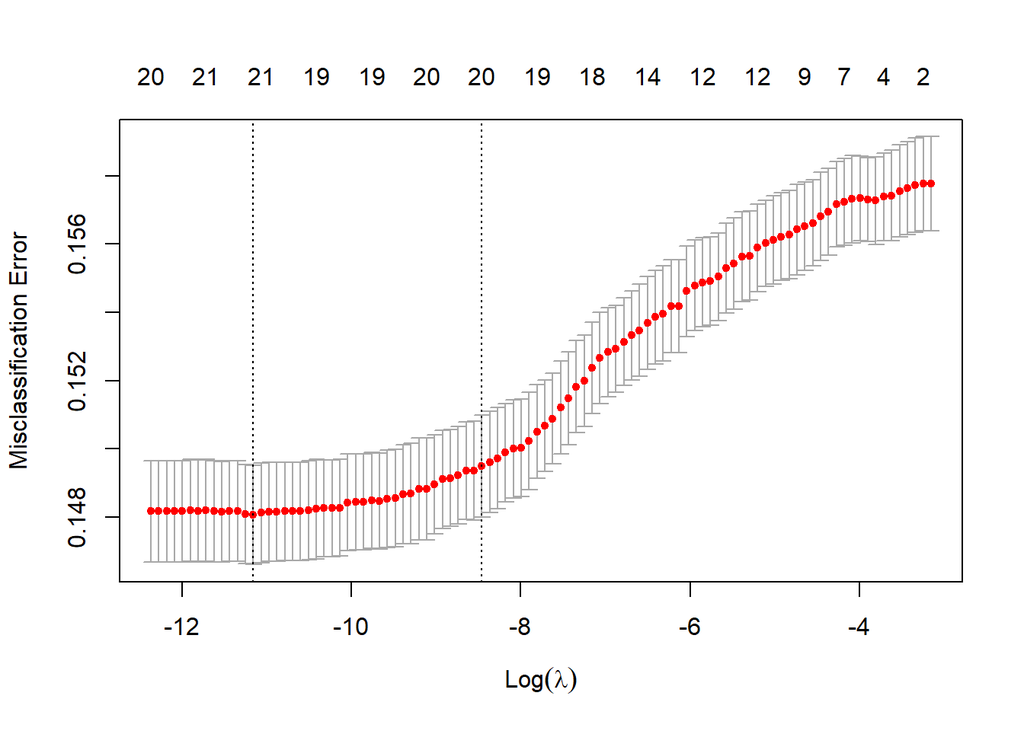

```r
set.seed(1)
cv.lasso <- cv.glmnet(x_train, y_train, alpha = 1, family = "binomial", type.measure = "class")
# alpha = 1 设置lasso惩戒项
plot(cv.lasso)
```

使在验证集上分类误差最小的lambda：

```r
cv.lasso$lambda.min
```

```
## [1] 1.428958e-05
```

为了避免过拟合,向上调整后的lambda：

```r
cv.lasso$lambda.1se
```

```
## [1] 0.0002121958
```

#### 1.1.2 对子测试集进行样本外拟合

```r
model <- glmnet(x_train, y_train, alpha = 1, family = "binomial",
                lambda = cv.lasso$lambda.min)
coef(model)
```

```
## 22 x 1 sparse Matrix of class "dgCMatrix"
##                              s0
## (Intercept)        6.570629e-02
## national_inv      -2.186296e-02
## lead_time         -8.295247e-02
## in_transit_qty    -2.407461e-02
## forecast_3_month  -3.913801e-05
## forecast_6_month   1.399118e-03
## forecast_9_month   .
## sales_1_month      5.916618e-03
## sales_3_month      7.350390e-03
## sales_6_month     -4.889135e-03
## sales_9_month      1.819526e-03
## min_bank           1.284789e-03
## potential_issue    1.238088e+00
## pieces_past_due    4.428023e-03
## perf_6_month_avg  -4.130592e-01
## perf_12_month_avg -4.063273e-01
## local_bo_qty       4.004036e-02
## deck_risk         -6.489342e-01
## oe_constraint      4.027452e+00
## ppap_risk          1.469896e-01
## stop_auto_buy     -9.640012e-02
## rev_stop          -9.560651e-01
```

```r
str(subtest)
```

```
## 'data.frame':    11784 obs. of  23 variables:
##  $ sku              : int  9 11 16 41 45 47 60 67 69 76 ...
##  $ national_inv     : int  0 1 9635 319 3 83 20 3 -2 3 ...
##  $ lead_time        : int  9 12 8 2 2 8 4 12 8 8 ...
##  $ in_transit_qty   : int  0 0 26 0 1 0 0 0 48 0 ...
##  $ forecast_3_month : int  1 0 0 0 8 0 0 0 408 0 ...
##  $ forecast_6_month : int  1 0 0 0 12 0 0 0 744 0 ...
##  $ forecast_9_month : int  1 0 0 0 20 0 0 0 996 0 ...
##  $ sales_1_month    : int  0 0 88 11 6 0 2 0 136 0 ...
##  $ sales_3_month    : int  0 1 267 20 15 1 2 0 386 0 ...
##  $ sales_6_month    : int  0 2 538 34 20 3 7 0 636 0 ...
##  $ sales_9_month    : int  0 2 875 51 32 7 7 3 1036 0 ...
##  $ min_bank         : int  0 2 97 3 2 1 1 0 304 0 ...
##  $ potential_issue  : int  0 0 0 0 0 0 0 0 0 0 ...
##  $ pieces_past_due  : int  0 0 0 0 0 0 0 0 36 0 ...
##  $ perf_6_month_avg : num  0.86 0.77 0.12 0.81 0.98 0.58 0.24 0.73 0.86 0.5 ...
##  $ perf_12_month_avg: num  0.69 0.73 0.12 0.77 0.96 0.57 0.14 0.79 0.88 0.4 ...
##  $ local_bo_qty     : int  0 0 0 0 0 0 0 0 41 0 ...
##  $ deck_risk        : int  0 1 0 0 0 0 1 0 0 0 ...
##  $ oe_constraint    : int  0 0 0 0 0 0 0 0 0 0 ...
##  $ ppap_risk        : int  0 0 0 0 0 0 0 0 0 0 ...
##  $ stop_auto_buy    : int  1 1 1 1 1 1 1 1 1 1 ...
##  $ rev_stop         : int  0 0 0 0 0 0 0 0 0 0 ...
##  $ went_on_backorder: int  0 0 0 0 1 0 0 0 1 0 ...
```

```r
x_test <- as.matrix(subtest[2:22]) # 去掉第一列

#prob <- predict(model, newx = x_test,type="class")
#pred <- ifelse(prob > 0.5, 1, 0)
pred <- predict(model, newx = x_test,type="class")
mean(pred == subtest[23])
```

```
## [1] 0.8523422
```

```r
confCV.logit <- table(subtest$went_on_backorder, pred) # 混淆矩阵
confCV.logit
```

```
##    pred
##        0    1
##   0 9874   51
##   1 1689  170
```

```r
accuracy.logit = (9874+170)/sum(confCV.logit)
accuracy.logit
```

```
## [1] 0.8523422
```

准确率为85.23%

### 1.2 Decision Tree

```r
library(tree)
library(e1071)
```

```r
library(rpart)
library(rpart.plot)
library(caret)
library(ROCR)
```

#### 1.2.1 模型训练及调参

通过10折交叉验证进行grid search选择参数——最优的模型复杂度

```r
fitControl <- trainControl(method = "cv", number = 10)
cpGrid <- expand.grid(.cp = (1:50)*0.001) #grid search complexity参数

set.seed(1)
cvResults <- train(as.factor(went_on_backorder) ~ .-sku, data = subtrain, method = "rpart", trControl = fitControl, tuneGrid = cpGrid) # 训练集上训练，方法rpart

cvResults
```

```
## CART
##
## 47135 samples
##    22 predictor
##     2 classes: '0', '1'
##
## No pre-processing
## Resampling: Cross-Validated (10 fold)
## Summary of sample sizes: 42423, 42421, 42422, 42421, 42421, 42421, ...
## Resampling results across tuning parameters:
##
##   cp     Accuracy   Kappa
##   0.001  0.9087513  0.6281448
##   0.002  0.9061205  0.6146565
##   0.003  0.9035746  0.6030337
##   0.004  0.9016228  0.5953855
##   0.005  0.9003711  0.5919050
##   0.006  0.8991831  0.5881680
##   0.007  0.8982920  0.5827033
##   0.008  0.8975495  0.5817448
##   0.009  0.8952583  0.5606931
##   0.010  0.8944308  0.5504148
##   0.011  0.8944308  0.5504148
##   0.012  0.8944308  0.5504148
##   0.013  0.8914605  0.5230459
##   0.014  0.8863689  0.4783360
##   0.015  0.8860931  0.4745872
##   0.016  0.8859234  0.4728151
##   0.017  0.8859234  0.4728151
##   0.018  0.8859234  0.4728151
##   0.019  0.8834202  0.4488558
##   0.020  0.8808104  0.4182372
##   0.021  0.8808104  0.4182372
##   0.022  0.8808104  0.4182372
##   0.023  0.8808104  0.4182372
##   0.024  0.8808104  0.4182372
##   0.025  0.8808104  0.4182372
##   0.026  0.8808104  0.4182372
##   0.027  0.8808104  0.4182372
##   0.028  0.8808104  0.4182372
```

[output cut: 10 more lines]

```
##   0.039  0.8808104  0.4182372
##   0.040  0.8808104  0.4182372
##   0.041  0.8808104  0.4182372
##   0.042  0.8808104  0.4182372
##   0.043  0.8808104  0.4182372
##   0.044  0.8808104  0.4182372
##   0.045  0.8808104  0.4182372
##   0.046  0.8808104  0.4182372
##   0.047  0.8808104  0.4182372
##   0.048  0.8808104  0.4182372
##   0.049  0.8808104  0.4182372
##   0.050  0.8808104  0.4182372
##
## Accuracy was used to select the optimal model using the largest value.
## The final value used for the model was cp = 0.001.
```

```r
dfTreeCV <- rpart(as.factor(went_on_backorder) ~ .-sku, data = subtrain, control = rpart.control(cp =cvResults["bestTune"])) #使用cv grid search 找出的最佳cp
```

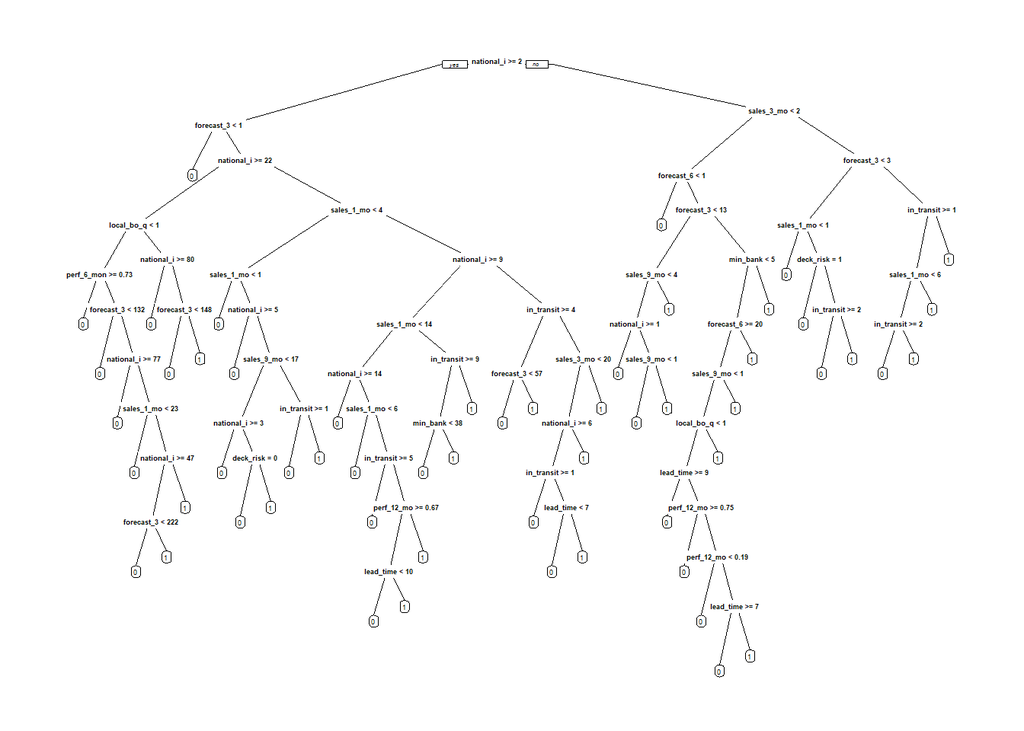

```r
prp(dfTreeCV)
```

[figure not shown]

```r
library(maptree)
draw.tree(dfTreeCV,nodeinfo=TRUE)
```

#### 1.2.2 对子测试集进行样本外测试

```r
subtestPred <- predict(dfTreeCV, newdata = subtest, type = "class")
confCV.dt <- table(subtest$went_on_backorder, subtestPred)
confCV.dt
```

```
##    subtestPred
##        0    1
##   0 9578  347
##   1  747 1112
```

```r
mean(subtestPred == subtest$went_on_backorder)
```

```
## [1] 0.9071623
```

决策树样本外准确率为90.72%，较Logit回归有较大进步。

```r
(9578+1112)/sum(confCV.dt)
```

```
## [1] 0.9071623
```

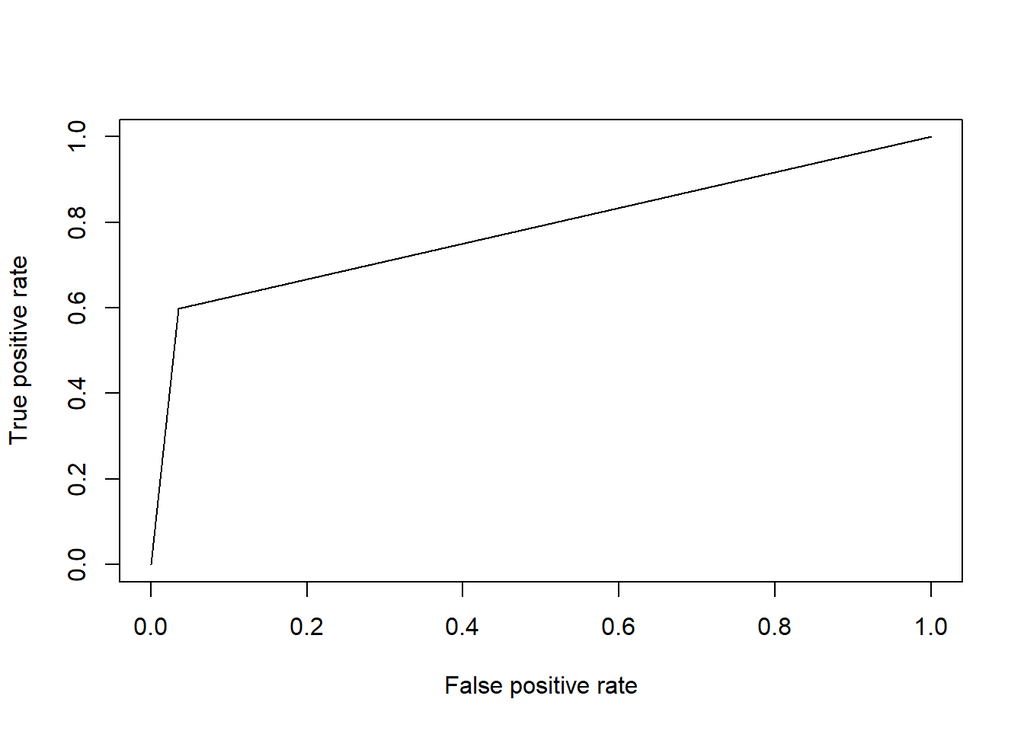

```r
pred <- prediction(c(subtestPred), subtest$went_on_backorder)
perf.dt <- performance(pred, "tpr", "fpr")
plot(perf.dt)
```

模型的ROC曲线

```r
auc.dt <- performance(pred, "auc")
auc.dt@y.values[[1]]
```

```
## [1] 0.7816044
```

可见决策树模型比Logit回归有着更高的准确性。

### 1.3 Random Forest

```r
library(randomForest)
set.seed(1)
dfForest <- randomForest(as.factor(went_on_backorder) ~ .-sku, data = subtrain, ntree = 500, nodesize = 25, mtry = 6, importance =TRUE)
```

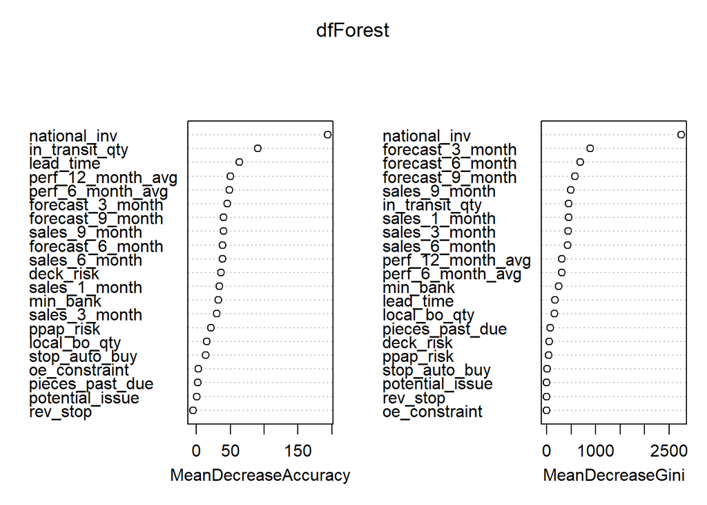

```r
varImpPlot(dfForest)
```

```r
predictForest <- predict(dfForest, newdata = subtest)
confRF <- table(subtest$went_on_backorder, predictForest)
confRF
```

```
##    predictForest
##        0    1
##   0 9627  298
##   1  644 1215
```

```r
accurRF <- (9627 + 1215)/sum(confRF)
#accurRF <- (9627 + 1215)/(9627 + 1215 + 299 + 643)
accurRF
```

```
## [1] 0.9200611
```

随机森林对于样本外准确度为92.01%，较决策树有小幅提升。

### 1.4 Boosting

```r
library (gbm)
set.seed (1)
dfBoost <- gbm(went_on_backorder~.-sku, data = subtrain, distribution= "bernoulli",n.trees =5000, interaction.depth =4) #"bernoulli" (logistic regression for 0-1 outcomes), "huberized" (huberized hinge loss for 0-1 outcomes), classes), "adaboost" (the AdaBoost exponential loss for 0-1 outcomes)

dfBoostPred <- predict (dfBoost, newdata =subtest,
n.trees =5000, type="response")
dfBoostPred.class = ifelse(dfBoostPred > 0.5,1,0)
```

```r
confBoost = table(subtest$went_on_backorder, dfBoostPred.class)
confBoost
```

```
##    dfBoostPred.class
##        0    1
##   0 9583  342
##   1  587 1272
```

```r
mean(dfBoostPred.class == subtest[23])
```

```
## [1] 0.9211643
```

gradient boosting的样本外准确度为92.12%,和随机森林并没有显著差异。 这部分得到了以下模型的**样本外准确度**： - logit regression with lasso penalty: 85.23% - dicision tree: 90.72% - random forest: 92.01% - gradient boosting: 92.12%

因此我们有理由认为random forest和gradient boosting对于该数据集有比较好的训练效果。

## 2. 模型训练和预测

通过对部分训练集的样本外测试结果，选择gradient boosting作为模型。由于gradient boosting和random forest在第一部分成绩相近，因此在这部分的最后也尝试了random forest。由于gradient boosting**样本内准确度**更高，提交的最终预测结果依然使用了gradient boosting作为模型，尽管这有可能带来过拟合的问题。

### 2.1 训练和调参

读入整个训练集

```r
train <- read.csv("train.csv")
```

```r
model <- gbm(went_on_backorder~.-sku, data = train, distribution= "bernoulli",n.trees =5000, interaction.depth =4,cv.folds=5) #"bernoulli"
# 用交叉检验确定最佳迭代次数
best.iter <- gbm.perf(model,method='cv')
```

[figure not shown]

```r
best.iter
```

```
## [1] 4545
```

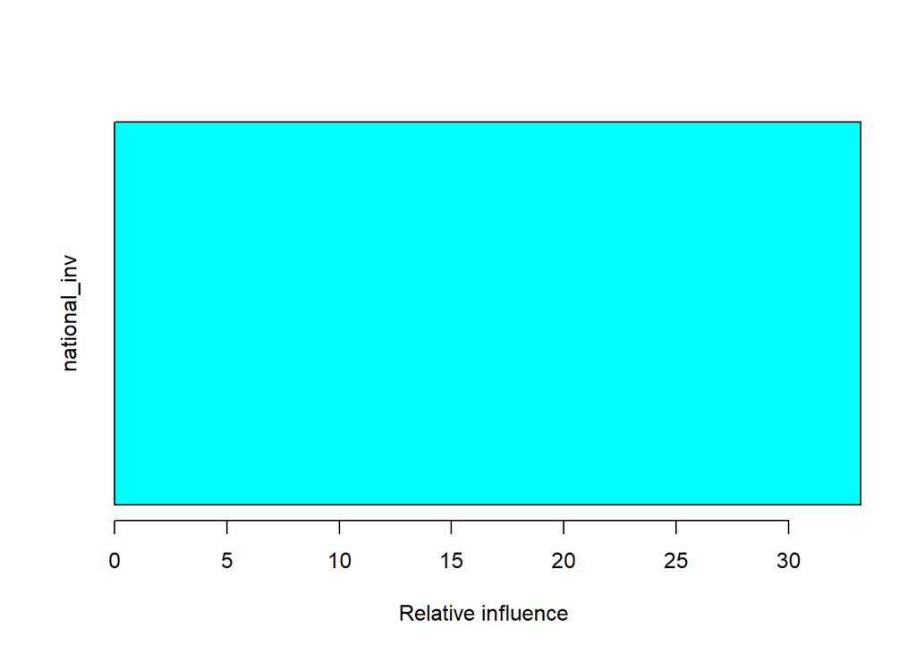

|  | var | rel.inf |
| --- | --- | --- |
| national_inv | national_inv | 33.21439306 |
| forecast_3_month | forecast_3_month | 12.73783100 |
| sales_1_month | sales_1_month | 7.14499545 |
| forecast_9_month | forecast_9_month | 6.75800337 |
| sales_9_month | sales_9_month | 6.38813063 |
| forecast_6_month | forecast_6_month | 6.03964827 |
| sales_3_month | sales_3_month | 4.82034837 |
| perf_12_month_avg | perf_12_month_avg | 4.16900331 |
| perf_6_month_avg | perf_6_month_avg | 4.11478292 |
| in_transit_qty | in_transit_qty | 3.71024436 |

[output cut: 11 more lines]

```r
summary(model,1,best.iter)
```

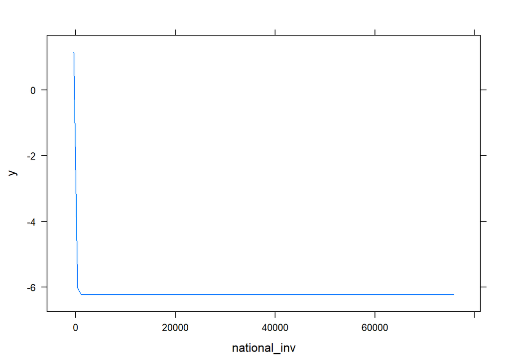

```r
plot.gbm(model,1,best.iter)
```

```r
train.predict = predict(model,newdata=train[-23],n.trees = best.iter,type="response")
train.predclass = ifelse(train.predict > 0.5,1,0)
```

样本内（训练集）准确度

```r
mean(train.predclass == train[23])
```

```
## [1] 0.9497955
```

0.9498 type=“bernoulli”

```r
conf = table(train.predclass,train$went_on_backorder)
conf
```

```
##
## train.predclass     0     1
##               0 48677  2011
##               1   947  7284
```

下图说明了0.5是一个很好的threshold:

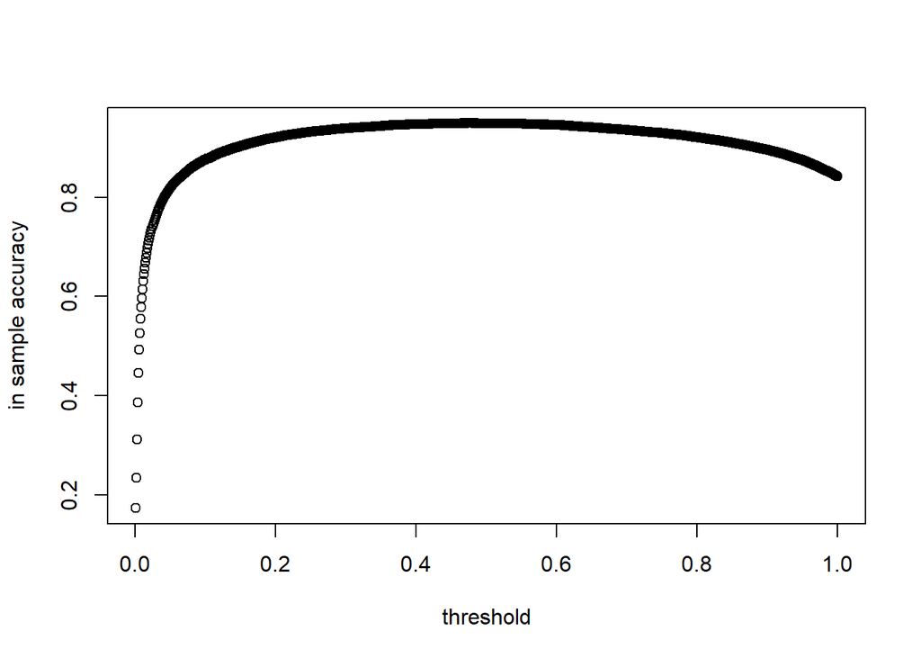

```r
x <- 1:1000
accuracyBoost <- vector(length=length(x))
for (ii in x){
   value <- x[ii]*0.001
   train.predclass <- ifelse(train.predict > value,1,0)
   accuracyBoost[ii] <- mean(train.predclass == train[23])
   #print(value)
   #print(accuracyBoost)
}
plot(x*0.001,accuracyBoost,xlab = "threshold", ylab = "in sample accuracy")
```

### 2.2 预测

```r
test <- read.csv("test.csv") #读入测试集

test.predict = predict(model,newdata=test,n.trees = best.iter, type = "response")

test.predclass = ifelse(test.predict > 0.5,1,0)

result <- read.csv("sampleSubmission.csv")
result$went_on_backorder = test.predclass

write.csv(result,"result.csv")
```

### 2.3 随机森林

```r
model2 <- randomForest(as.factor(went_on_backorder) ~ .-sku, data = train, ntree = 500, nodesize = 25, mtry = 6, importance =TRUE)
```

样本内预测

```r
model2.predict <- predict(model2, data = train[-23])
conf.model2 <- table(train$went_on_backorder, model2.predict)
conf.model2
```

```
##    model2.predict
##         0     1
##   0 48072  1552
##   1  3083  6212
```

```r
model2.accurRF <- (48072 + 6212)/sum(conf.model2)
model2.accurRF
```

```
## [1] 0.9213327
```

样本外预测

```r
test.predictRF = predict(model2,newdata=test)

resultRF <- read.csv("sampleSubmission.csv")
resultRF$went_on_backorder = test.predictRF

write.csv(resultRF,"resultRF.csv")
```